# R Notebook

```r
rm(list=ls()) #clear the workspace
```

```r
DTMC.SRLM<-function(total.t, landscape, e.rate, c.rate, alpha, gamma, epsilon,
                    self.rec, r.on, r.off, P.mat){

  n<-n.patches

    #1) SETTING UP ALL OUR PARAMETERS FOR THE SRLM's ODEs
  n.patches<-length(landscape$patch.ID)
  x.coord<-landscape$x.coord
  y.coord<-landscape$y.coord
  areas<-landscape$areas
  #calculate the extinction rate for each patch
  extinction.rates<-e.rate/areas
  #calculate delta
  delta<-e.rate/c.rate
  # construct the distance matrix
  dist.mat<-matrix(rep(0,n.patches*n.patches),n.patches,n.patches)
  for (i in 1:n.patches){
    for (j in 1:n.patches){
      dist.mat[i,j]<-sqrt((x.coord[i]-x.coord[j])^2+(y.coord[i]-y.coord[j])^2)
    }
  }
  #CHECK: dist.mat
  #Getting the f(dij) values to plug into the rhs
  f.vals<-disp.kernel(dist.mat,alpha,gamma,epsilon,self.rec,n.patches)
  #CHECK: f.vals
  f.vals<-as.vector(f.vals)
  f.names<-matrix(rep(NA,n.patches*n.patches),n.patches,n.patches)
  for (i in 1:n.patches){
    for (j in 1:n.patches){
      f.names[i,j]<-paste0("f.vals",i,j)
    }
  }
  f.names<-as.vector(f.names)

  #2) SET THE INITIAL CONDITIONS
  #initial habitat configuration of patches on/off
  config<-rbinom(n.patches, 1, 0.5)
  #initial occupancy levels
  new.ICs<-0.5*config
  #configs.data<-config

  ########################################################################
  ########################################################################
  #STUFF SO WE DON"T HAVE TO FLIP PATCHES ON AND OFF ALL THE TIME AND CAN
  #JUST PICK CONFIGURATIONS IN OUR SIMULATIONS
  #########################################################################
  #1. START IN THE INITIAL CONFIGURATION
  #since we'll just keep track of the state associated with each configuration
  #rather than updating the configuration over and over again in the simulation
  #let's convert the configuration in to the row/column index that corresponds to that state
  #Because of how P.mat is ordered, with the first half of the matrix rows
  #corresponding to the first patch in the config being off, the first half
  #of those corresponding to the 2nd patch being off as well, and so on...
  #the following algorithm should provide us with which row corresponds to
  #our current configuration
  for (i in 1:n){
    if (i==1) {
      if (config[n+1-i]==0){x<-2^0} else {x<-2^1}
    } else {
      if (i>1) {
        if (config[n+1-i]==0){x<-x+0} else {x<-x+2^(i-1)}
      }
    }
  }
  #1. create a dataframe with all possible configurations
  #so we can quickly convert state x to a config throughout the simulation
  #and save on storing configs for every timestep
  #ordered according to the sequence they occur as rows in our transition matrix
  #NOTE: updated to store these as sparse matrices to save memory :)
  all.configs <- Matrix(0, nrow=2^n, ncol=n, sparse=TRUE) #sparse matrix version
  #all.configs<-matrix(rep(NA, (2^n)*n), nrow=2^n, ncol=n) #no sparse matrix version
  for (i in 1:n){
  #if (i==1){BB<-c(0,1) #no sparse vector version
  if (i==1){BB<-as(c(0,1), "sparseVector") #sparse vector version
  }else{BB<-c(BB[1:(2^(i-2))],BB,BB[((2^(i-2))+1):(2^(i-1))])}
  all.configs[,(n-i+1)]<-t(rep(BB,2^(n-i)))}
  #######################################################################
  ########################################################################

  #3) BEGIN THE SIMULATION
  t<-0
  time.limit<-total.t #you can remove the time.limit if you want
  while (x>1 & t<time.limit) { #while at least one patch remains on

        ################################################################
        #Find the time to the next transition the good old fashioned way:
        #i.e. simulate the DTMC until a transition occurs
        tau<-0
        x.new<-sample((1:2^n), size=1, prob=P.mat[x,])
        while (x==x.new){ #while we are stuck in one state
          tau<-tau+1 #and keeping track of how much time is spent in the same state
          x.new<-sample((1:2^n), size=1, prob=P.mat[x,]) #simulate the transition of the DTMC
        } #when we finally make a transition to a new state, BEFORE WE MAKE THAT TRANSITION,
        #let's simulate the SRLM over the time we spent in that state...

        #set the initial config for the SRLM to the previous state
        config<-all.configs[x,]

        #3.3 A) SOLVE THE SRLM BASED ON THE INITIAL CONDITIONS BETWEEN NOW AND TAU
        #run the SRLM for the specified time tau, using initial conditions
        #new.ICs and relevant parameters
        #patches for which the "config=0" are left out
        #making sure "off" patches don't colonize or get colonized in the rhs of the ODE system

    #3.3 A1) CREATE A NAMED LIST OF PARAMETERS FOR THE SRLM ODEs
    #creating a list of the parameters we calculated to be passed to our ODE function
    ############################################
    parameter.names<-c("n.patches", "c.rate", "self.rec",
             rep(paste0("extinction.rates",1:n.patches)),
             rep(paste0("x.coord",1:n.patches)),
             rep(paste0("y.coord",1:n.patches)),
             rep(paste0("areas",1:n.patches)),
             rep(paste0("config",1:n.patches))
             ,f.names)
    parameter.values<-c(n.patches,c.rate,self.rec,extinction.rates,x.coord,y.coord,areas,config
              ,f.vals)
    parameters<-list(c(setNames(parameter.values, parameter.names)))
    ###########################################

    #3.3 A2) Setting our initial values for the SRLM ODE
    ###########################################
    IC.names<-rep(paste0("p",1:n.patches))
    IC.values<-new.ICs
    p<-setNames(IC.values,IC.names)
    ###########################################

    #3.3 A3) Make sure tau is not <1 or this will create an error in the ODE solver
    if (tau<=1){ #if tau is less than one it will be rounded to 0 which will produce an error in ode
      tau<-1 #so if tau is less than 1, let it be rounded up to 1
    }

    #3.3 A4) SOLVE AND FORMAT OUTPUT INTO A DATA TABLE
    output<-ode(SRLM.ODE, parameters,times=seq(0,round(tau, 0),1),y=new.ICs)
    #shift the time by the already accumulated time (t) and append to past values
    output<-data.frame(output)
    output$time<-output$time+t
    if (t==0){sim.data<-output
    configs.data<-c(t, config)}
    if (t!=0){sim.data<-rbind(sim.data, output)
    configs.data<-rbind(configs.data, c(t, config))}

    #NOW we can switch to the next configuration
    x<-x.new

        #3.2 UPDATE THE TIME ELAPSED IN SIMULATION
        t<-t+tau

      } #end of while loop

  end.t<-t #time to absorption or simulation end
  return(list(sim.data=sim.data, configs.data=configs.data))
}
```

TESTING

Load the necessary packages and functions

```r
library("pracma")
library("deSolve")
library("ggplot2")
source("create_landscape_func.r")
source("SRLMODE_func.r")
source("at_equilibrium_rootfunc.r")
source("dispersal_kernel_func.r")
source("lambda_M_func.r")
source("quasi_eq_sparseDTMC_func.r")
```

Setting up our parameters

```r
total.t<-200#10 #total time to run the model (optional; could run to absorption)
landscape<-create.landscape(n.patches=4, landscape.type="linear", landscape.limit=100,
                            patch.distribution="uniform", areas.distribution="uniform", areas.limit=1,
                            clustering.iters=0)
n.patches<-length(landscape$patch.ID)
e.rate<-0.1#0.3
c.rate<-4#0.5
alpha<-0.1 #inverse of the mean dispersal distances (negetive exponential)
#network structure parameters:
gamma<-0
epsilon<-n.patches #1
self.rec<-1
#rates of vents turning off to on and on to off respectively
r.on<-0.02
r.off<-0.01
####################################################################################################
#Initial.Lm<-3000
#first let's scale our e.rate and c.rate to ensure a high enough persistence capacity the
#metapopulation has the opportunity to experience some growth
#delta<-Initial.Lm/(get.lambda.M(landscape=landscape, alpha=alpha, e.rate=e.rate, c.rate=c.rate, self.rec=self.rec, gamma=gamma, epsilon=epsilon))
#delta
#e.rate<-1
#c.rate<-1/delta
#lambda.M<-get.lambda.M(landscape=landscape, alpha=alpha, e.rate=e.rate, c.rate=c.rate, self.rec=self.rec, gamma=gamma, epsilon=epsilon)*delta
#lambda.M
```

Running our simulation

```r
stuff<-quasi.eq(n.patches, r.on, r.off)
sim.data<-DTMC.SRLM(total.t, landscape, e.rate, c.rate, alpha, gamma, epsilon, self.rec, r.on, r.off, P.mat=stuff$P.mat)
  sim.data<-sim.data[[1]]
  sim.data
```

| time | X1 | X2 | X3 | X4 |
| --- | --- | --- | --- | --- |
| 0 | 0.0000000 | 0.0000000 | 0.5000000 | 0.5000000 |
| 1 | 0.0000000 | 0.0000000 | 0.9635012 | 0.9635012 |
| 2 | 0.0000000 | 0.0000000 | 0.9766984 | 0.9766984 |
| 3 | 0.0000000 | 0.0000000 | 0.9768934 | 0.9768934 |
| 4 | 0.0000000 | 0.0000000 | 0.9768964 | 0.9768964 |
| 5 | 0.0000000 | 0.0000000 | 0.9768965 | 0.9768965 |
| 6 | 0.0000000 | 0.0000000 | 0.9768965 | 0.9768965 |
| 7 | 0.0000000 | 0.0000000 | 0.9768965 | 0.9768965 |
| 8 | 0.0000000 | 0.0000000 | 0.9768965 | 0.9768965 |
| 9 | 0.0000000 | 0.0000000 | 0.9768965 | 0.9768965 |

[output cut: 198 more lines]

If we wanted to weight the occupancy of patches by the size (carrying capacity of the patch)

```r
#weight the occupancy values by area and plot metapop size over time
area.weights<-landscape$areas/sum(landscape$areas)
metapop.size<-sim.data[,-1]*area.weights
```

But we also want to plot just the total occupancy across the metapopulation so let’s sum the occupancies of each patch

```r
metapop.size<-rowSums(sim.data[,-1]) #*area.weights) #<-if we wanted to including weighting by patch areas
time<-sim.data$time
```

Make a plot looking at the metapopulation size over time

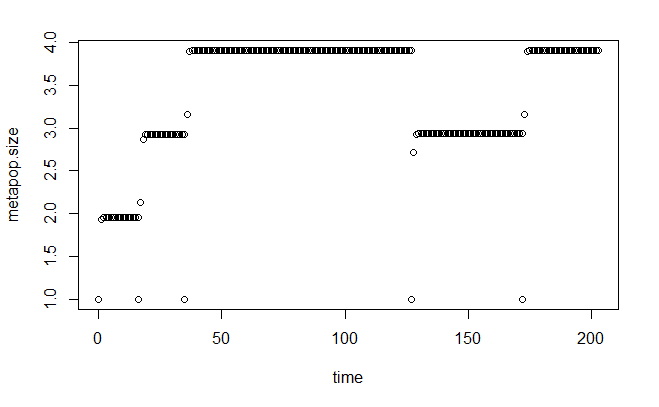

```r
plot(time, metapop.size)
```

Testing the transition limit version:

```r
source("DTMC_and_SRLM_func_w_transition_limit.r")
```

Setting up our parameters

```r
total.trans<-200#10 #total time to run the model (optional; could run to absorption)
landscape<-create.landscape(n.patches=4, landscape.type="linear", landscape.limit=100,
                            patch.distribution="uniform", areas.distribution="uniform", areas.limit=1,
                            clustering.iters=0)
n.patches<-length(landscape$patch.ID)
e.rate<-0.1#0.3
c.rate<-4#0.5
alpha<-0.1 #inverse of the mean dispersal distances (negetive exponential)
#network structure parameters:
gamma<-0
epsilon<-n.patches #1
self.rec<-1
#rates of vents turning off to on and on to off respectively
r.on<-0.02
r.off<-0.01
####################################################################################################
#Initial.Lm<-3000
#first let's scale our e.rate and c.rate to ensure a high enough persistence capacity the
#metapopulation has the opportunity to experience some growth
#delta<-Initial.Lm/(get.lambda.M(landscape=landscape, alpha=alpha, e.rate=e.rate, c.rate=c.rate, self.rec=self.rec, gamma=gamma, epsilon=epsilon))
#delta
#e.rate<-1
#c.rate<-1/delta
#lambda.M<-get.lambda.M(landscape=landscape, alpha=alpha, e.rate=e.rate, c.rate=c.rate, self.rec=self.rec, gamma=gamma, epsilon=epsilon)*delta
#lambda.M
```

Running our simulation

```r
stuff<-quasi.eq(n.patches, r.on, r.off)
P.mat<-stuff$P.mat
sim.data<-DTMC.SRLM(total.trans, landscape, e.rate, c.rate, alpha, gamma, epsilon, self.rec, r.on, r.off, P.mat)
  sim.data<-sim.data[[1]]
  sim.data
```

| time | X1 | X2 | X3 | X4 |
| --- | --- | --- | --- | --- |
| 0 | 0.0000000 | 0.5000000 | 0.5000000 | 0.0000000 |
| 1 | 0.0000000 | 0.9635012 | 0.9635012 | 0.0000000 |
| 2 | 0.0000000 | 0.9766984 | 0.9766984 | 0.0000000 |
| 3 | 0.0000000 | 0.9768934 | 0.9768934 | 0.0000000 |
| 4 | 0.0000000 | 0.9768964 | 0.9768964 | 0.0000000 |
| 5 | 0.0000000 | 0.9768965 | 0.9768965 | 0.0000000 |
| 6 | 0.0000000 | 0.9768965 | 0.9768965 | 0.0000000 |
| 7 | 0.0000000 | 0.9768965 | 0.9768965 | 0.0000000 |
| 8 | 0.0000000 | 0.9768965 | 0.9768965 | 0.0000000 |
| 9 | 0.0000000 | 0.9768965 | 0.9768965 | 0.0000000 |

[output cut: 264 more lines]

If we wanted to weight the occupancy of patches by the size (carrying capacity of the patch)

```r
#weight the occupancy values by area and plot metapop size over time
area.weights<-landscape$areas/sum(landscape$areas)
metapop.size<-sim.data[,-1]*area.weights
```

But we also want to plot just the total occupancy across the metapopulation so let’s sum the occupancies of each patch

```r
metapop.size<-rowSums(sim.data[,-1]) #*area.weights) #<-if we wanted to including weighting by patch areas
time<-sim.data$time
```

Make a plot looking at the metapopulation size over time

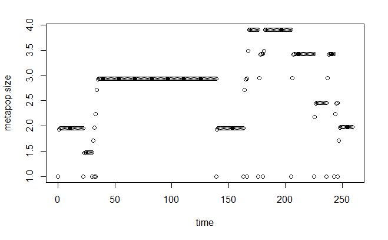

```r
plot(time, metapop.size)
```

SOME TEST SIMS TO COMPARE TO MY CTMC SIMS:

```r
source("DTMC_and_SRLM_func_w_transition_limit.r")
```

Setting up our parameters

```r
#r.offs<-c(1/100000,1/10000,1/1000,1/100,1/10)
#r.ons<-c(1/100,1/10,1)
#alphas<-c(10,1/10,1/100) #avg. disp = 1/10 interpatch distance, the interpatch distance and global disp

landscape<-create.landscape(n.patches=4, landscape.type="linear", landscape.limit=100,
                            patch.distribution="uniform", areas.distribution="uniform", areas.limit=1,
                            clustering.iters=0)
print(ggplot(landscape, aes(x.coord,y.coord)) + theme_classic() + geom_point(aes(size = areas)))
```

[output not shown]

```r
n.patches<-length(landscape$patch.ID) #for future use

total.trans<-1000#10 #total time to run the model (optional; could run to absorption)
n.patches<-length(landscape$patch.ID)
e.rate<-0.1#0.3
c.rate<-4#0.5
alpha<-1/100 #inverse of the mean dispersal distances (negetive exponential)
#network structure parameters:
gamma<-0
epsilon<-n.patches #1
self.rec<-1
#rates of vents turning off to on and on to off respectively
r.on<-1
r.off<-1/10000
####################################################################################################
#Initial.Lm<-3000
#first let's scale our e.rate and c.rate to ensure a high enough persistence capacity the
#metapopulation has the opportunity to experience some growth
#delta<-Initial.Lm/(get.lambda.M(landscape=landscape, alpha=alpha, e.rate=e.rate, c.rate=c.rate, self.rec=self.rec, gamma=gamma, epsilon=epsilon))
#delta
#e.rate<-1
#c.rate<-1/delta
#lambda.M<-get.lambda.M(landscape=landscape, alpha=alpha, e.rate=e.rate, c.rate=c.rate, self.rec=self.rec, gamma=gamma, epsilon=epsilon)*delta
#lambda.M
```

Running our simulation

```r
stuff<-quasi.eq(n.patches, r.on, r.off)
P.mat<-stuff$P.mat
sim.data<-DTMC.SRLM(total.trans, landscape, e.rate, c.rate, alpha, gamma, epsilon, self.rec, r.on, r.off, P.mat)
  configs.data<-sim.data[[2]]
  configs.data
```

```
                [,1] [,2] [,3] [,4] [,5]
configs.data       0    0    1    0    0
                   1    1    1    0    1
                   2    1    1    1    1
                1245    1    0    1    1
                1246    1    1    1    1
                1280    1    1    1    0
                1281    1    1    1    1
                7316    1    1    0    1
                7320    1    1    1    1
               11815    1    1    1    0
               11816    1    1    1    1
               13221    1    1    1    0
               13222    1    1    1    1
               17650    0    1    1    1
```

[output cut: 187 more lines]

Note: r.off=1x10^-5 won’t compute, but r.off=1x10^-4 is fine but only for a small number of patches

Plotting the number of patches on

```r
tot.on<-rowSums(configs.data[,-1]) #*area.weights) #<-if we wanted to including weighting by patch areas
time<-configs.data[,1]
```

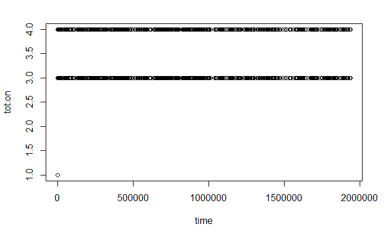

```r
plot(time, tot.on)
```

Setting up our parameters

```r
#r.offs<-c(1/100000,1/10000,1/1000,1/100,1/10)
#r.ons<-c(1/100,1/10,1)
#alphas<-c(10,1/10,1/100) #avg. disp = 1/10 interpatch distance, the interpatch distance and global disp

landscape<-create.landscape(n.patches=4, landscape.type="linear", landscape.limit=100,
                            patch.distribution="uniform", areas.distribution="uniform", areas.limit=1,
                            clustering.iters=0)
print(ggplot(landscape, aes(x.coord,y.coord)) + theme_classic() + geom_point(aes(size = areas)))
```

[output not shown]

```r
n.patches<-length(landscape$patch.ID) #for future use

total.trans<-1000#10 #total time to run the model (optional; could run to absorption)
n.patches<-length(landscape$patch.ID)
e.rate<-0.1#0.3
c.rate<-4#0.5
alpha<-1/100 #inverse of the mean dispersal distances (negetive exponential)
#network structure parameters:
gamma<-0
epsilon<-n.patches #1
self.rec<-1
#rates of vents turning off to on and on to off respectively
r.on<-1
r.off<-1/10
####################################################################################################
#Initial.Lm<-3000
#first let's scale our e.rate and c.rate to ensure a high enough persistence capacity the
#metapopulation has the opportunity to experience some growth
#delta<-Initial.Lm/(get.lambda.M(landscape=landscape, alpha=alpha, e.rate=e.rate, c.rate=c.rate, self.rec=self.rec, gamma=gamma, epsilon=epsilon))
#delta
#e.rate<-1
#c.rate<-1/delta
#lambda.M<-get.lambda.M(landscape=landscape, alpha=alpha, e.rate=e.rate, c.rate=c.rate, self.rec=self.rec, gamma=gamma, epsilon=epsilon)*delta
#lambda.M
```

Running our simulation

```r
stuff<-quasi.eq(n.patches, r.on, r.off)
P.mat<-stuff$P.mat
sim.data<-DTMC.SRLM(total.trans, landscape, e.rate, c.rate, alpha, gamma, epsilon, self.rec, r.on, r.off, P.mat)
  configs.data<-sim.data[[2]]
  configs.data
```

```
             [,1] [,2] [,3] [,4] [,5]
configs.data    0    0    0    1    0
                1    0    1    1    0
                2    0    0    1    1
                3    1    0    1    1
                4    1    1    1    1
                5    1    0    1    0
                6    0    1    1    0
                7    1    1    1    1
               23    1    1    0    1
               24    1    0    1    1
               25    1    1    1    0
               26    1    1    1    1
               27    1    1    1    0
               28    1    1    1    1
```

[output cut: 34 more lines]

Note: r.off=1x10^-5 won’t compute, but r.off=1x10^-4 is fine but only for a small number of patches

Plotting the number of patches on

```r
tot.on<-rowSums(configs.data[,-1]) #*area.weights) #<-if we wanted to including weighting by patch areas
time<-configs.data[,1]
```

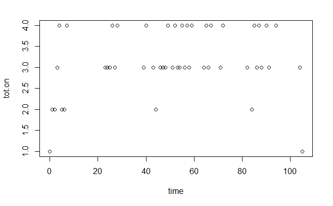

```r
plot(time, tot.on)
```

Now let’s compare that against the CTMC and SRLM version

```r
source("CTMC_and_SRLM_func_w_transition_limit.r")
```

Setting up our parameters

```r
#r.offs<-c(1/100000,1/10000,1/1000,1/100,1/10)
#r.ons<-c(1/100,1/10,1)
#alphas<-c(10,1/10,1/100) #avg. disp = 1/10 interpatch distance, the interpatch distance and global disp

landscape<-create.landscape(n.patches=4, landscape.type="linear", landscape.limit=100,
                            patch.distribution="uniform", areas.distribution="uniform", areas.limit=1,
                            clustering.iters=0)
print(ggplot(landscape, aes(x.coord,y.coord)) + theme_classic() + geom_point(aes(size = areas)))
```

[output not shown]

```r
n.patches<-length(landscape$patch.ID) #for future use

total.trans<-1000#10 #total time to run the model (optional; could run to absorption)
n.patches<-length(landscape$patch.ID)
e.rate<-0.1#0.3
c.rate<-4#0.5
alpha<-1/100 #inverse of the mean dispersal distances (negetive exponential)
#network structure parameters:
gamma<-0
epsilon<-n.patches #1
self.rec<-1
#rates of vents turning off to on and on to off respectively
r.on<-1
r.off<-1/10000
####################################################################################################
#Initial.Lm<-3000
#first let's scale our e.rate and c.rate to ensure a high enough persistence capacity the
#metapopulation has the opportunity to experience some growth
#delta<-Initial.Lm/(get.lambda.M(landscape=landscape, alpha=alpha, e.rate=e.rate, c.rate=c.rate, self.rec=self.rec, gamma=gamma, epsilon=epsilon))
#delta
#e.rate<-1
#c.rate<-1/delta
#lambda.M<-get.lambda.M(landscape=landscape, alpha=alpha, e.rate=e.rate, c.rate=c.rate, self.rec=self.rec, gamma=gamma, epsilon=epsilon)*delta
#lambda.M
```

```r
sim.data<-CTMC.SRLM(total.trans, landscape=landscape, e.rate, c.rate, alpha, gamma, epsilon, self.rec, r.on, r.off)
  configs.data<-sim.data[[2]]
  configs.data
```

```
                     [,1] [,2] [,3] [,4] [,5]
configs.data 0.000000e+00    1    0    0    0
             1.456756e-01    1    0    0    1
             3.939492e-01    1    0    1    1
             3.947274e-01    1    1    1    1
             4.936903e+02    0    1    1    1
             4.946368e+02    1    1    1    1
             1.214852e+03    0    1    1    1
             1.216886e+03    1    1    1    1
             3.302845e+03    1    0    1    1
             3.303656e+03    1    1    1    1
             4.410271e+03    1    1    0    1
             4.410406e+03    1    1    1    1
             9.302143e+03    0    1    1    1
             9.302861e+03    1    1    1    1
             1.440808e+04    1    1    0    1
             1.440815e+04    1    1    1    1
             1.679908e+04    1    1    1    0
             1.679996e+04    1    1    1    1
             2.081285e+04    0    1    1    1
             2.081340e+04    1    1    1    1
             2.093011e+04    1    1    1    0
             2.093316e+04    1    1    1    1
             2.774945e+04    1    0    1    1
             2.775086e+04    1    1    1    1
             2.817923e+04    1    1    0    1
             2.818063e+04    1    1    1    1
             3.507880e+04    1    0    1    1
             3.508088e+04    1    1    1    1
             3.592166e+04    1    1    0    1
             3.592240e+04    1    1    1    1
             3.868900e+04    1    1    0    1
             3.868984e+04    1    1    1    1
             3.966735e+04    1    0    1    1
             3.966819e+04    1    1    1    1
             4.275099e+04    1    0    1    1
             4.275110e+04    1    1    1    1
             4.362375e+04    1    1    1    0
             4.362447e+04    1    1    1    1
             4.699651e+04    1    1    1    0
```

[output cut: 147 more lines]

```
             2.134328e+05    1    0    1    1
             2.134333e+05    1    1    1    1
             2.139029e+05    0    1    1    1
             2.139041e+05    1    1    1    1
             2.158664e+05    0    1    1    1
             2.158666e+05    1    1    1    1
             2.167812e+05    1    0    1    1
             2.167812e+05    1    1    1    1
             2.191521e+05    1    0    1    1
             2.191522e+05    1    1    1    1
             2.197146e+05    1    1    0    1
             2.197149e+05    1    1    1    1
             2.295861e+05    1    0    1    1
             2.295866e+05    1    1    1    1
 [ reached getOption("max.print") -- omitted 800 rows ]
```

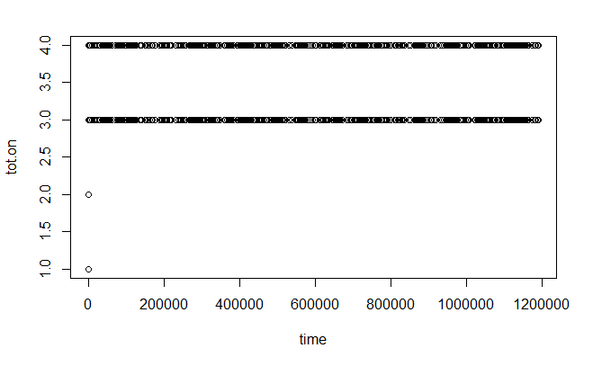

```r
tot.on<-rowSums(configs.data[,-1]) #*area.weights) #<-if we wanted to including weighting by patch areas
time<-configs.data[,1]
plot(time, tot.on)
```

Setting up our parameters

```r
#r.offs<-c(1/100000,1/10000,1/1000,1/100,1/10)
#r.ons<-c(1/100,1/10,1)
#alphas<-c(10,1/10,1/100) #avg. disp = 1/10 interpatch distance, the interpatch distance and global disp

landscape<-create.landscape(n.patches=4, landscape.type="linear", landscape.limit=100,
                            patch.distribution="uniform", areas.distribution="uniform", areas.limit=1,
                            clustering.iters=0)
print(ggplot(landscape, aes(x.coord,y.coord)) + theme_classic() + geom_point(aes(size = areas)))
```

[output not shown]

```r
n.patches<-length(landscape$patch.ID) #for future use

total.trans<-1000#10 #total time to run the model (optional; could run to absorption)
n.patches<-length(landscape$patch.ID)
e.rate<-0.1#0.3
c.rate<-4#0.5
alpha<-1/100 #inverse of the mean dispersal distances (negetive exponential)
#network structure parameters:
gamma<-0
epsilon<-n.patches #1
self.rec<-1
#rates of vents turning off to on and on to off respectively
r.on<-1
r.off<-1/10
####################################################################################################
#Initial.Lm<-3000
#first let's scale our e.rate and c.rate to ensure a high enough persistence capacity the
#metapopulation has the opportunity to experience some growth
#delta<-Initial.Lm/(get.lambda.M(landscape=landscape, alpha=alpha, e.rate=e.rate, c.rate=c.rate, self.rec=self.rec, gamma=gamma, epsilon=epsilon))
#delta
#e.rate<-1
#c.rate<-1/delta
#lambda.M<-get.lambda.M(landscape=landscape, alpha=alpha, e.rate=e.rate, c.rate=c.rate, self.rec=self.rec, gamma=gamma, epsilon=epsilon)*delta
#lambda.M
```

```r
sim.data<-CTMC.SRLM(total.trans, landscape=landscape, e.rate, c.rate, alpha, gamma, epsilon, self.rec, r.on, r.off)
configs.data<-sim.data[[2]]
```

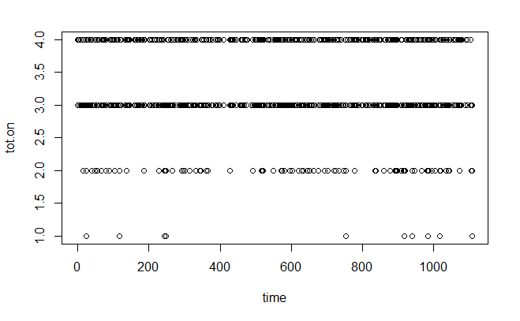

```r
tot.on<-rowSums(configs.data[,-1]) #*area.weights) #<-if we wanted to including weighting by patch areas
time<-configs.data[,1]
plot(time, tot.on)
```